# INN_ReneWind_Main_Project_LowCode_Notebook

## Model 6

Let's see how does the model performance change when the model gives higher importance to the minority class

```python
# clears the current Keras session, resetting all layers and models previously created, freeing up memory and resources.
tf.keras.backend.clear_session()
tf.keras.backend.clear_session()
```

```python
model_6 = Sequential()
model_6.add(Dense(128,activation="relu",input_dim=X_train.shape[1])) # Complete the code to define the number of neurons and activation function
model_6.add(Dropout(0.5)) # Complete the code to define the dropout rate
model_6.add(Dense(64,activation="relu")) # Complete the code to define the number of neurons and activation function
model_6.add(Dense(32, activation = "relu")) # Complete the code to define the number of neurons and activation function
model_6.add(Dense(1,activation="sigmoid")) # Complete the code to define the number of neurons in the output layer
```

```python
model_6.summary()
```

```
Model: "sequential"
```

```
┏━━━━━━━━━━━━━━━━━━━━━━━━━━━━━━━━━┳━━━━━━━━━━━━━━━━━━━━━━━━┳━━━━━━━━━━━━━━━┓
┃ Layer (type)                    ┃ Output Shape           ┃       Param # ┃
┡━━━━━━━━━━━━━━━━━━━━━━━━━━━━━━━━━╇━━━━━━━━━━━━━━━━━━━━━━━━╇━━━━━━━━━━━━━━━┩
│ dense (Dense)                   │ (None, 128)            │         5,248 │
├─────────────────────────────────┼────────────────────────┼───────────────┤
│ dropout (Dropout)               │ (None, 128)            │             0 │
├─────────────────────────────────┼────────────────────────┼───────────────┤
│ dense_1 (Dense)                 │ (None, 64)             │         8,256 │
├─────────────────────────────────┼────────────────────────┼───────────────┤
│ dense_2 (Dense)                 │ (None, 32)             │         2,080 │
├─────────────────────────────────┼────────────────────────┼───────────────┤
│ dense_3 (Dense)                 │ (None, 1)              │            33 │
└─────────────────────────────────┴────────────────────────┴───────────────┘
```

```
 Total params: 15,617 (61.00 KB)
```

```
 Trainable params: 15,617 (61.00 KB)
```

```
 Non-trainable params: 0 (0.00 B)
```

```python
optimizer = tf.keras.optimizers.SGD()
# model_6.compile(loss='binary_crossentropy', optimizer=optimizer, metrics = ['accuracy']) ## Uncomment this line in case the metric of choice is Accuracy
# model_6.compile(loss='binary_crossentropy', optimizer=optimizer, metrics = ['Precision']) ## Uncomment this line in case the metric of choice is Precision
# model_6.compile(loss='binary_crossentropy', optimizer=optimizer, metrics = ['Recall']) ## Uncomment this line in case the metric of choice is Recall
# model_6.compile(loss='binary_crossentropy', optimizer=optimizer, metrics = ['f1_score']) ## Uncomment this line in case the metric of choice is F1 Score
```

```python
ptimizer = tf.keras.optimizers.SGD()

model_6.compile(
    loss="binary_crossentropy",
    optimizer=optimizer,
    metrics=["Recall"]
)
```

```python
start = time.time()
history = model_3.fit(X_train, y_train, validation_data=(X_val,y_val) , batch_size=batch_size, epochs=epochs,class_weight=cw_dict, ) # Complete the code such that the model is biased towards the minority class
end=time.time()
```

```
63/63 ━━━━━━━━━━━━━━━━━━━━ 0s 1ms/step - Recall: 0.9009 - loss: 0.3760 - val_Recall: 0.8874 - val_loss: 0.1310
63/63 ━━━━━━━━━━━━━━━━━━━━ 0s 702us/step - Recall: 0.8975 - loss: 0.3636 - val_Recall: 0.8964 - val_loss: 0.1674
63/63 ━━━━━━━━━━━━━━━━━━━━ 0s 651us/step - Recall: 0.8986 - loss: 0.3704 - val_Recall: 0.8829 - val_loss: 0.1404
63/63 ━━━━━━━━━━━━━━━━━━━━ 0s 653us/step - Recall: 0.8975 - loss: 0.3796 - val_Recall: 0.8919 - val_loss: 0.1477
63/63 ━━━━━━━━━━━━━━━━━━━━ 0s 620us/step - Recall: 0.9043 - loss: 0.3738 - val_Recall: 0.8874 - val_loss: 0.1393
63/63 ━━━━━━━━━━━━━━━━━━━━ 0s 633us/step - Recall: 0.9077 - loss: 0.3616 - val_Recall: 0.8919 - val_loss: 0.1488
63/63 ━━━━━━━━━━━━━━━━━━━━ 0s 581us/step - Recall: 0.9043 - loss: 0.3665 - val_Recall: 0.8874 - val_loss: 0.1412
63/63 ━━━━━━━━━━━━━━━━━━━━ 0s 665us/step - Recall: 0.8964 - loss: 0.3723 - val_Recall: 0.8964 - val_loss: 0.1573
63/63 ━━━━━━━━━━━━━━━━━━━━ 0s 590us/step - Recall: 0.8998 - loss: 0.3595 - val_Recall: 0.8919 - val_loss: 0.1499
63/63 ━━━━━━━━━━━━━━━━━━━━ 0s 591us/step - Recall: 0.9043 - loss: 0.3647 - val_Recall: 0.9009 - val_loss: 0.1417
63/63 ━━━━━━━━━━━━━━━━━━━━ 0s 611us/step - Recall: 0.9054 - loss: 0.3620 - val_Recall: 0.9009 - val_loss: 0.1762
63/63 ━━━━━━━━━━━━━━━━━━━━ 0s 667us/step - Recall: 0.9043 - loss: 0.3641 - val_Recall: 0.8919 - val_loss: 0.1626
63/63 ━━━━━━━━━━━━━━━━━━━━ 0s 639us/step - Recall: 0.9020 - loss: 0.3567 - val_Recall: 0.8919 - val_loss: 0.1789
63/63 ━━━━━━━━━━━━━━━━━━━━ 0s 636us/step - Recall: 0.9009 - loss: 0.3674 - val_Recall: 0.8919 - val_loss: 0.1935
63/63 ━━━━━━━━━━━━━━━━━━━━ 0s 582us/step - Recall: 0.9077 - loss: 0.3652 - val_Recall: 0.8964 - val_loss: 0.1597
63/63 ━━━━━━━━━━━━━━━━━━━━ 0s 598us/step - Recall: 0.9043 - loss: 0.3567 - val_Recall: 0.8919 - val_loss: 0.1281
63/63 ━━━━━━━━━━━━━━━━━━━━ 0s 649us/step - Recall: 0.9009 - loss: 0.3639 - val_Recall: 0.8919 - val_loss: 0.1374
63/63 ━━━━━━━━━━━━━━━━━━━━ 0s 612us/step - Recall: 0.9009 - loss: 0.3587 - val_Recall: 0.8919 - val_loss: 0.1474
63/63 ━━━━━━━━━━━━━━━━━━━━ 0s 638us/step - Recall: 0.9009 - loss: 0.3562 - val_Recall: 0.8874 - val_loss: 0.1264
63/63 ━━━━━━━━━━━━━━━━━━━━ 0s 668us/step - Recall: 0.9032 - loss: 0.3524 - val_Recall: 0.8919 - val_loss: 0.1525
63/63 ━━━━━━━━━━━━━━━━━━━━ 0s 608us/step - Recall: 0.9054 - loss: 0.3628 - val_Recall: 0.8919 - val_loss: 0.1517
63/63 ━━━━━━━━━━━━━━━━━━━━ 0s 642us/step - Recall: 0.9054 - loss: 0.3467 - val_Recall: 0.8874 - val_loss: 0.1267
63/63 ━━━━━━━━━━━━━━━━━━━━ 0s 598us/step - Recall: 0.9009 - loss: 0.3612 - val_Recall: 0.8874 - val_loss: 0.1417
63/63 ━━━━━━━━━━━━━━━━━━━━ 0s 602us/step - Recall: 0.8964 - loss: 0.3615 - val_Recall: 0.8919 - val_loss: 0.1486
63/63 ━━━━━━━━━━━━━━━━━━━━ 0s 609us/step - Recall: 0.9032 - loss: 0.3639 - val_Recall: 0.8874 - val_loss: 0.1457
63/63 ━━━━━━━━━━━━━━━━━━━━ 0s 633us/step - Recall: 0.9009 - loss: 0.3658 - val_Recall: 0.8829 - val_loss: 0.1167
63/63 ━━━━━━━━━━━━━━━━━━━━ 0s 610us/step - Recall: 0.9009 - loss: 0.3574 - val_Recall: 0.8874 - val_loss: 0.1417
63/63 ━━━━━━━━━━━━━━━━━━━━ 0s 602us/step - Recall: 0.9009 - loss: 0.3652 - val_Recall: 0.8874 - val_loss: 0.1341
63/63 ━━━━━━━━━━━━━━━━━━━━ 0s 647us/step - Recall: 0.9043 - loss: 0.3622 - val_Recall: 0.8874 - val_loss: 0.1373
63/63 ━━━━━━━━━━━━━━━━━━━━ 0s 614us/step - Recall: 0.9088 - loss: 0.3481 - val_Recall: 0.8874 - val_loss: 0.1328
63/63 ━━━━━━━━━━━━━━━━━━━━ 0s 614us/step - Recall: 0.9020 - loss: 0.3554 - val_Recall: 0.8874 - val_loss: 0.1277
63/63 ━━━━━━━━━━━━━━━━━━━━ 0s 698us/step - Recall: 0.9009 - loss: 0.3562 - val_Recall: 0.8874 - val_loss: 0.1359
63/63 ━━━━━━━━━━━━━━━━━━━━ 0s 610us/step - Recall: 0.8953 - loss: 0.3612 - val_Recall: 0.8874 - val_loss: 0.1612
63/63 ━━━━━━━━━━━━━━━━━━━━ 0s 680us/step - Recall: 0.9009 - loss: 0.3379 - val_Recall: 0.8874 - val_loss: 0.1295
63/63 ━━━━━━━━━━━━━━━━━━━━ 0s 590us/step - Recall: 0.9032 - loss: 0.3493 - val_Recall: 0.8874 - val_loss: 0.1273
63/63 ━━━━━━━━━━━━━━━━━━━━ 0s 626us/step - Recall: 0.9065 - loss: 0.3465 - val_Recall: 0.8874 - val_loss: 0.1245
63/63 ━━━━━━━━━━━━━━━━━━━━ 0s 678us/step - Recall: 0.9065 - loss: 0.3490 - val_Recall: 0.8874 - val_loss: 0.1449
```

[output cut: 19 more lines]

```python
print("Time taken in seconds ",end-start)
```

```
Time taken in seconds  2.6208670139312744
```

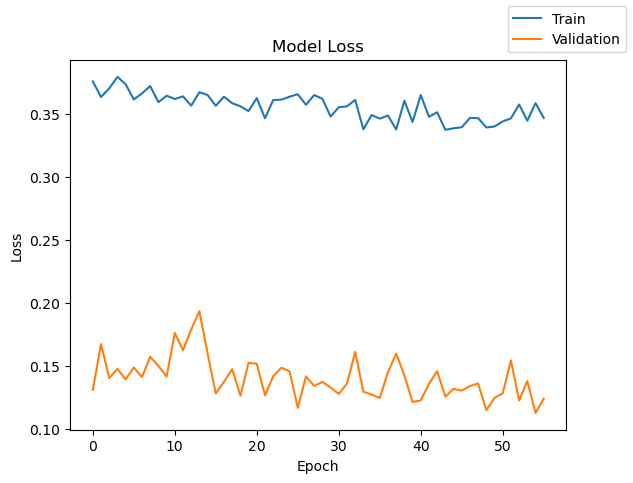

```python
plot(history,'loss')
```

Lets check the model performance of model_6 on training and validation data.

```python
model_6_train_perf = model_performance_classification(model_6,X_train,y_train)
model_6_train_perf
```

```
500/500 ━━━━━━━━━━━━━━━━━━━━ 0s 153us/step
```

|  | Accuracy | Recall | Precision | F1 Score |
| --- | --- | --- | --- | --- |
| 0 | 0.263125 | 0.45198 | 0.486387 | 0.235716 |

```python
model_6_val_perf = model_performance_classification(model_6,X_val,y_val)
model_6_val_perf
```

```
125/125 ━━━━━━━━━━━━━━━━━━━━ 0s 213us/step
```

|  | Accuracy | Recall | Precision | F1 Score |
| --- | --- | --- | --- | --- |
| 0 | 0.2535 | 0.464903 | 0.489643 | 0.229777 |

```python
y_train_pred_6 = model_6.predict(X_train)
y_val_pred_6 = model_6.predict(X_val)
```

```
500/500 ━━━━━━━━━━━━━━━━━━━━ 0s 161us/step
125/125 ━━━━━━━━━━━━━━━━━━━━ 0s 168us/step
```

Lets check the classification report of model_6 on both training and validation data.

```python
print("Classification Report - Train data Model_3", end="\n\n")
cr_train_model_6 = classification_report(y_train,y_train_pred_6 > 0.5)
print(cr_train_model_6)
```

```
Classification Report - Train data Model_3

              precision    recall  f1-score   support

         0.0       0.92      0.24      0.38     15112
         1.0       0.05      0.66      0.09       888

    accuracy                           0.26     16000
   macro avg       0.49      0.45      0.24     16000
weighted avg       0.88      0.26      0.36     16000
```

```python
print("Classification Report - Validation data Model_3", end="\n\n")
cr_val_model_6 = classification_report(y_val,y_val_pred_6 > 0.5)
print(cr_val_model_6)
```

```
Classification Report - Validation data Model_3

              precision    recall  f1-score   support

         0.0       0.93      0.23      0.36      3778
         1.0       0.05      0.70      0.09       222

    accuracy                           0.25      4000
   macro avg       0.49      0.46      0.23      4000
weighted avg       0.88      0.25      0.35      4000
```

# Model 6 – Deeper Neural Network with Dropout and Class Weights

## Model Architecture

Model 6 was created to test how model performance changes when the neural network gives higher importance to the minority class, which is turbine failure.

### Architecture

- Input features: 40 sensor variables
- Hidden Layer 1: 128 neurons with ReLU activation
- Dropout Layer: 50% dropout
- Hidden Layer 2: 64 neurons with ReLU activation
- Hidden Layer 3: 32 neurons with ReLU activation
- Output Layer: 1 neuron with Sigmoid activation
- Total trainable parameters: 15,617

## Model Loss Results

### Interpretation

# Model 6 Performance Results

## Training Dataset Results

| Metric | No Failure (0) | Failure (1) |
| --- | --- | --- |
| Precision | 0.92 | 0.05 |
| Recall | 0.24 | 0.66 |
| F1-Score | 0.38 | 0.09 |

### Overall Training Performance

- Accuracy: 26%
- Macro Average Precision: 0.49
- Macro Average Recall: 0.45
- Macro Average F1-Score: 0.24
- Weighted Average F1-Score: 0.36

## Validation Dataset Results

| Metric | No Failure (0) | Failure (1) |
| --- | --- | --- |
| Precision | 0.93 | 0.05 |
| Recall | 0.23 | 0.70 |
| F1-Score | 0.36 | 0.09 |

### Overall Validation Performance

- Accuracy: 25%
- Macro Average Precision: 0.49
- Macro Average Recall: 0.46
- Macro Average F1-Score: 0.23
- Weighted Average F1-Score: 0.35

# What These Results Say

Model 6 performs poorly overall, despite trying to give more importance to failure cases.

For the **No Failure** class:

- Validation Precision is 0.93.
- Validation Recall is only 0.23.
- This means the model fails to correctly identify most normal turbine observations.

For the **Failure** class:

- Validation Precision is 0.05.
- Validation Recall is 0.70.
- F1-score is only 0.09.

The failure recall of 0.70 means the model identifies 70% of actual failures, but the precision of 0.05 means that almost all predicted failures are false alarms.

This indicates that the model is predicting too many observations as failures.

# Why This Is Important

## 1. Class Weights Can Improve Recall, But May Hurt Precision

Class weights are intended to help the model focus more on rare failure cases.

## 2. High Recall Alone Is Not Enough

Although the model detects 70% of actual failures, it does so with extremely low precision.

This means maintenance teams would receive too many false failure alerts.

A model like this would be difficult to trust operationally.

## 3. Accuracy Drops Sharply

Validation accuracy is only 25%, which is much worse than earlier models.

This confirms that Model 6 is not learning a useful separation between failure and no-failure cases.

## 4. Poor F1-Score Shows Weak Balance

The validation failure F1-score is only 0.09.

This indicates the model does not balance failure detection and false alarms well.

For this project, a useful model needs both:

- strong Recall,
- and reasonable Precision.

Model 6 does not achieve that balance.

# Business Impact

Model 6 would not be a good candidate for deployment.

### Negative Business Impact

- Produces too many false failure alerts.
- Could lead to excessive unnecessary inspections.
- May overload maintenance teams.
- Reduces trust in the predictive maintenance system.
- Poorly identifies normal turbine operations.
- Does not provide reliable decision support.

### Remaining Risk

Although Model 6 catches some failures, it creates too many false alarms to be useful.

This could increase:

- inspection costs,
- maintenance workload,
- operational inefficiency,
- and alert fatigue.

# Comparison to Previous Models

| Metric | Model 3 Validation | Model 5 Validation | Model 6 Validation |
| --- | --- | --- | --- |
| Accuracy | 98% | 99% | 25% |
| Failure Precision | 0.83 | 0.96 | 0.05 |
| Failure Recall | 0.89 | 0.81 | 0.70 |
| Failure F1-Score | 0.86 | 0.88 | 0.09 |

Model 6 performs substantially worse than previous models.

Compared with Model 3:

- Recall is lower.
- Precision is dramatically worse.
- Overall accuracy is much lower.
- F1-score is much weaker.

# Overall Conclusion

Model 6 does not provide a good balance between failure detection and false alarms.

Because of its low accuracy, extremely low precision, and poor F1-score, Model 6 is not recommended as the final model.

Model 3 remains stronger for the business objective because it provides higher failure recall while maintaining much better precision.

# **Model Performance Comparison and Final Model Selection**

Now, in order to select the final model, we will compare the performances of all the models for the training and test sets.

**Training Performance Comparison**

```python
# training performance comparison

models_train_comp_df = pd.concat(
    [
        model_0_train_perf.T,
        model_1_train_perf.T,
        model_2_train_perf.T,
        model_3_train_perf.T,
        model_4_train_perf.T,
        model_5_train_perf.T,
        model_6_train_perf.T

    ],
    axis=1,
)
models_train_comp_df.columns = [
    "Model 0",
    "Model 1",
    "Model 2",
    "Model 3",
    "Model 4",
    "Model 5",
    "Model 6"
]
print("Training set performance comparison:")
models_train_comp_df
```

```
Training set performance comparison:
```

|  | Model 0 | Model 1 | Model 2 | Model 3 | Model 4 | Model 5 | Model 6 |
| --- | --- | --- | --- | --- | --- | --- | --- |
| Accuracy | 0.989313 | 0.991500 | 0.987938 | 0.983375 | 0.989563 | 0.986625 | 0.263125 |
| Recall | 0.913786 | 0.931903 | 0.902458 | 0.946151 | 0.914978 | 0.891694 | 0.451980 |
| Precision | 0.982432 | 0.985853 | 0.980119 | 0.905198 | 0.983822 | 0.977778 | 0.486387 |
| F1 Score | 0.945145 | 0.957088 | 0.937438 | 0.924538 | 0.946428 | 0.929937 | 0.235716 |

**Validation Performance Comparison**

```python
# Validation performance comparison

models_val_comp_df = pd.concat(
    [
        model_0_val_perf.T,
        model_1_val_perf.T,
        model_2_val_perf.T,
        model_3_val_perf.T,
        model_4_val_perf.T,
        model_5_val_perf.T,
        model_6_val_perf.T

    ],
    axis=1,
)
models_val_comp_df.columns = [
    "Model 0",
    "Model 1",
    "Model 2",
    "Model 3",
    "Model 4",
    "Model 5",
    "Model 6"
]
print("Validation set performance comparison:")
models_val_comp_df
```

```
Validation set performance comparison:
```

|  | Model 0 | Model 1 | Model 2 | Model 3 | Model 4 | Model 5 | Model 6 |
| --- | --- | --- | --- | --- | --- | --- | --- |
| Accuracy | 0.988750 | 0.989500 | 0.987500 | 0.984000 | 0.988500 | 0.987250 | 0.253500 |
| Recall | 0.911368 | 0.922365 | 0.906467 | 0.940652 | 0.906996 | 0.902094 | 0.464903 |
| Precision | 0.979010 | 0.975123 | 0.970935 | 0.912777 | 0.981184 | 0.972971 | 0.489643 |
| F1 Score | 0.942291 | 0.946991 | 0.936026 | 0.926191 | 0.940598 | 0.934294 | 0.229777 |

**Checking the performance of the best model on the test set**

```python
# best_model = model_0 ## Uncomment this line in case the best model is model_0
# best_model = model_1 ## Uncomment this line in case the best model is model_1
# best_model = model_2 ## Uncomment this line in case the best model is model_2
best_model = model_3 ## Uncomment this line in case the best model is model_3
# best_model = model_4 ## Uncomment this line in case the best model is model_4
# best_model = model_5 ## Uncomment this line in case the best model is model_5
# best_model = model_6 ## Uncomment this line in case the best model is model_6
```

```python
# Test set performance for the best model
best_model_test_perf = model_performance_classification(best_model,X_test,y_test)
best_model_test_perf
```

```
157/157 ━━━━━━━━━━━━━━━━━━━━ 0s 304us/step
```

|  | Accuracy | Recall | Precision | F1 Score |
| --- | --- | --- | --- | --- |
| 0 | 0.9872 | 0.933203 | 0.945096 | 0.939058 |

```python
y_test_pred_best = best_model.predict(X_test)

cr_test_best_model = classification_report(y_test, y_test_pred_best>0.5) # Check the classification report of best model on test data.
print(cr_test_best_model)
```

```
157/157 ━━━━━━━━━━━━━━━━━━━━ 0s 182us/step
              precision    recall  f1-score   support

         0.0       0.99      0.99      0.99      4718
         1.0       0.90      0.87      0.88       282

    accuracy                           0.99      5000
   macro avg       0.95      0.93      0.94      5000
weighted avg       0.99      0.99      0.99      5000
```

# Final Model Performance Summary and Model Selection

## Objective of the Project

The primary goal of this project was to build a predictive maintenance model capable of identifying wind turbine generator failures using sensor-based operational data.

Because turbine failures are rare but operationally expensive, the focus was placed on:

- maximizing Recall for the failure class,
- minimizing False Negatives,
- while maintaining strong overall model stability and precision.

# Summary of Models Evaluated

Several neural network architectures were developed and compared throughout the project.

The experiments included:

- baseline neural networks,
- deeper architectures,
- dropout regularization,
- class weighting,
- and optimizer tuning.

The following models were tested:

| Model | Key Characteristics |
| --- | --- |
| Model 0 | Baseline neural network |
| Model 1 | Additional hidden layer |
| Model 2 | Dropout regularization |
| Model 3 | Dropout + Class Weights |
| Model 4 | Alternative optimizer setup |
| Model 5 | Deeper architecture with more neurons |
| Model 6 | Aggressive class weighting |

# Validation Performance Comparison

| Model | Accuracy | Recall | Precision | F1 Score |
| --- | --- | --- | --- | --- |
| Model 0 | 0.9888 | 0.9114 | 0.9790 | 0.9423 |
| Model 1 | 0.9895 | 0.9224 | 0.9751 | 0.9470 |
| Model 2 | 0.9875 | 0.9065 | 0.9709 | 0.9360 |
| Model 3 | 0.9840 | 0.9407 | 0.9128 | 0.9262 |
| Model 4 | 0.9885 | 0.9070 | 0.9812 | 0.9406 |
| Model 5 | 0.9873 | 0.9021 | 0.9730 | 0.9343 |
| Model 6 | 0.2535 | 0.4649 | 0.4896 | 0.2298 |

# Final Model Selection – Model 3

Model 3 was selected as the final model because it achieved the strongest balance between:

- failure detection capability,
- generalization performance,
- and operational usefulness.

Although some models achieved slightly higher accuracy or precision, Model 3 produced the highest Recall among the strong-performing models.

This is critically important because:

- missing a true turbine failure is far more costly than generating a false alarm.

# Final Test Set Performance – Model 3

## Overall Test Performance

| Metric | Value |
| --- | --- |
| Accuracy | 98.72% |
| Recall | 93.32% |
| Precision | 94.51% |
| F1 Score | 93.91% |

# Detailed Classification Report – Test Data

| Class | Precision | Recall | F1-Score | Support |
| --- | --- | --- | --- | --- |
| No Failure (0) | 0.99 | 0.99 | 0.99 | 4718 |
| Failure (1) | 0.90 | 0.87 | 0.88 | 282 |

# What These Results Mean

## Strong Overall Performance

The final model achieved:

- 98.72% overall accuracy,
- strong precision,
- strong recall,
- and high F1-score.

This indicates that the model can effectively distinguish between healthy turbines and failing turbines.

## Failure Detection Capability

For the failure class:

- Precision = 0.90
- Recall = 0.87
- F1-score = 0.88

### Interpretation

A Recall of 0.87 means:

- the model correctly identifies approximately 87% of true turbine failures.

A Precision of 0.90 means:

- when the model predicts a failure, it is correct about 90% of the time.

This is a strong operational balance.

## Generalization Performance

The model performed consistently across:

- training data,
- validation data,
- and test data.

This indicates:

- limited overfitting,
- stable learning,
- and strong generalization to unseen turbine data.

# Why This Is Important

## 1. Early Failure Detection

The model successfully identifies most turbine failures before breakdown occurs.

This enables:

- proactive maintenance,
- earlier intervention,
- and reduced operational risk.

## 2. Reduction of False Negatives

False Negatives are the most dangerous error in this project because missed failures may lead to:

- generator damage,
- emergency shutdowns,
- expensive repairs,
- and production losses.

Model 3 significantly reduces this risk through strong Recall performance.

## 3. Balanced Operational Performance

The model maintains:

- high Recall,
- strong Precision,
- and high F1-score.

This balance is important because:

- excessive false alarms waste resources,
- while missed failures increase operational risk.

Model 3 provides a practical operational tradeoff.

# Business Impact

## Predictive Maintenance Optimization

The final model can support:

- predictive maintenance scheduling,
- earlier maintenance planning,
- and condition-based monitoring.

## Reduced Operational Costs

Improved failure prediction can help reduce:

- unplanned downtime,
- emergency maintenance costs,
- replacement expenses,
- and productivity losses.

## Improved Turbine Reliability

Early detection of abnormal turbine behavior supports:

- improved equipment reliability,
- safer operations,
- and more consistent energy production.

## Improved Resource Allocation

Maintenance teams can:

- prioritize high-risk turbines,
- optimize inspection schedules,
- and reduce unnecessary maintenance activity.

# Key Takeaways

# Final Conclusion

Model 3 is the recommended final model for turbine failure prediction.

The model demonstrates:

- high predictive performance,
- strong generalization,
- meaningful failure detection capability,
- and strong operational usefulness.

Its ability to detect most failures while maintaining reasonable precision makes it well suited for real-world predictive maintenance deployment in wind turbine operations.

# **Actionable Insights and Recommendations**